# Enrichment of CpGs effected by passage in genome features

### Backgorund CpG List to compare to

CpGs which have an passage=0 intercept <0.15 need to be excluded from the hypomethylayed background. Since they start <0.15 they can decrease by >0.15 as there is a lower limit of 0. CpGs which have an passage=0 intercept >0.85 need to be excluded from the hypermethylayed background. Since they start >0.15 they can increase by >0.15 as there is a upper limit of 1.

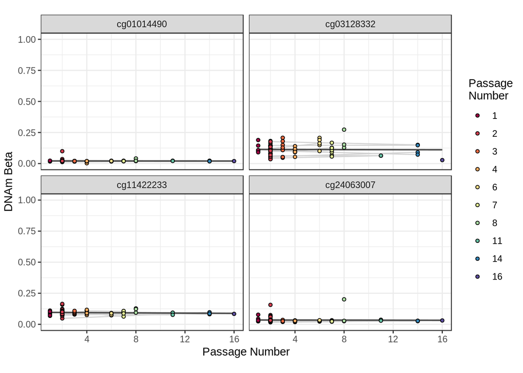

```r
intercepts<-sapply(1:nrow(organoid_beta), function(x) as.numeric(lm(organoid_beta[x,]~epic.organoid$passage.or.rescope.no_numeric)$coefficients[1]))

rm_hypo<-rownames(organoid_beta)[which(intercepts<=0.15)]
rm_hyper<-rownames(organoid_beta)[which(intercepts>=0.85)]
plt_hetero(rm_hypo[1:4])
```

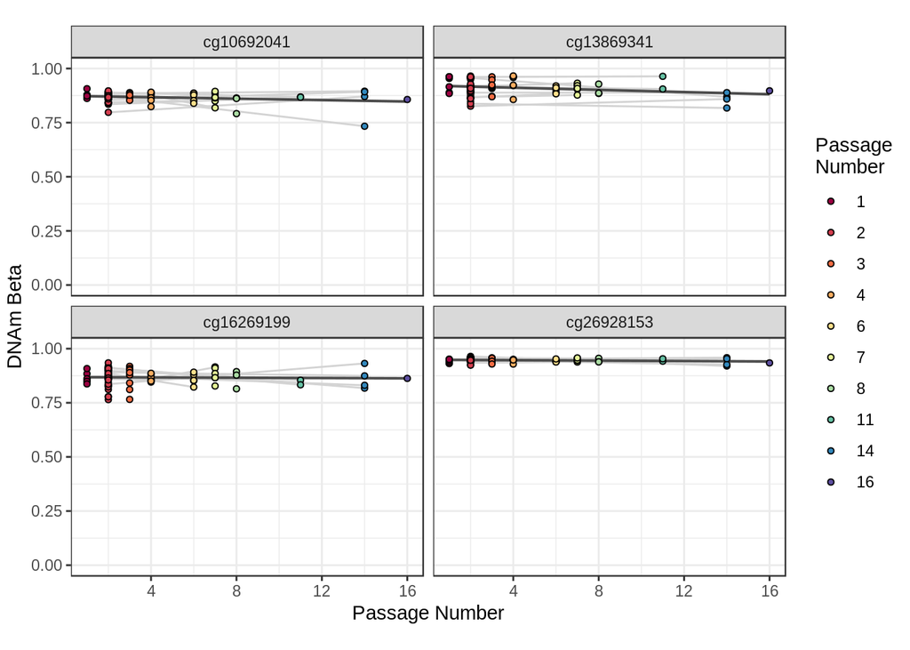

```r
plt_hetero(rm_hyper[1:4])
```

```r
background_hypo<-background[which(!(background$IlmnID%in%rm_hypo)),]
background_hyper<-background[which(!(background$IlmnID%in%rm_hyper)),]
```

## c-DMR enrichment of passage CpGs

c-DMRs are from # https://www.nature.com/articles/ng.298#Sec25 supplementary data 2 The paper does not list the genome build but they DNAm was measured on the Nimblegen CHARM array. The GEO page for the Nimblegen CHARM array used does say is it hg18 (GRch36)

```r
cDMR<-read.csv(here("data","EPIC_Features_cDMR36.csv"))
dim(cDMR)
```

```
## [1] 800383      4
```

Most CpGs don’t have an associated cDMR, but here is an example with one.

```r
cDMR[110:120,]
```

```
##       X Unnamed..0         X0            X1
## 110 109        109 cg11420685            []
## 111 110        110 cg00039070            []
## 112 111        111 cg24796272            []
## 113 112        112 cg20259501            []
## 114 113        113 cg24851364 [0.383520852]
## 115 114        114 cg24506916            []
## 116 115        115 cg13643060            []
## 117 116        116 cg20390814            []
## 118 117        117 cg03434319            []
## 119 118        118 cg07469408            []
## 120 119        119 cg07176589            []
```

remove []

```r
cDMR$X1<-gsub("\\[|\\]","", cDMR$X1)
print(paste("There are ",length(irizarry_sup_cDMR<-cDMR$X0[which(cDMR$X1!="")])," CpGs overlapping a cDMR",sep="") )
```

```
## [1] "There are 7302 CpGs overlapping a cDMR"
```

```r
anno_EPIC<-anno_EPIC[which(anno_EPIC$IlmnID%in%cDMR$X0),]
```

Illumina annotation includes a CDMR column, so will compare to see my annotation is close But they don’t have direction, just yes no

```r
illumina_cDMR<-anno_EPIC$IlmnID[which(anno_EPIC$DMR=="CDMR")] # 6581
print(paste("There are ",length(illumina_cDMR)," CpGs overlapping a cDMR",sep="") )
```

```
## [1] "There are 6581 CpGs overlapping a cDMR"
```

```r
print(paste("Of the ",length(illumina_cDMR)," CpGs overlapping a cDMR, my annotation captures ",length(intersect(irizarry_sup_cDMR, illumina_cDMR))," of them.",sep="") )
```

```
## [1] "Of the 6581 CpGs overlapping a cDMR, my annotation captures 6581 of them."
```

Why do I have more? which of my cDMR CpG are not in cDMR according to illumina

```r
x<-irizarry_sup_cDMR[which(!(irizarry_sup_cDMR%in%illumina_cDMR))]
nrow(x)
```

```r
x<-anno_EPIC[which(anno_EPIC$IlmnID%in%x),c("IlmnID","DMR","Chromosome_36", "Coordinate_36")]
table(x$DMR)
```

```
##
##       DMR RDMR
##    8    5  708
```

Of the 721 cDMR CpG not called in cDMR by illumna 713 of these are because it looks like illumina did not allow for multiple entries in the DMR column. So there is no CpG annotated as both RDMR CDMR and therefore there are less CDMR than should be based on irizarry supplement And there are 8 cases where the CpG is on DMR boundary and I called as in and Illumina as out tidy up the cDMR file

```r
cDMR<-cDMR[,3:4]
colnames(cDMR)<-c("CpG", "cancer_db")
# 15 CpGs are in 2 cDMR. Fortunately in all cases the delta beta for these cDMRs are in the same direction so a mean will be taken
cDMR$cancer_db_mean<-sapply(1:nrow(cDMR), function(x){
  mean(as.numeric(strsplit(cDMR$cancer_db[x], ",")[[1]]))
})
```

the change in methylation are from the cDRm paper where “DeltaM is cancer minus normal”

```r
cDMR$cDMR<-sapply(1:nrow(cDMR), function(x){
  if(is.finite(cDMR$cancer_db_mean[x])){
    if(cDMR$cancer_db_mean[x]>=0){"cDMR with more DNAm in cancer"}else{
      if(cDMR$cancer_db_mean[x]<=0){"cDMR with less DNAm in cancer"}}}else("Not cDMR")
})

# view the same CpG again
cDMR[110:120,]
```

```
##            CpG   cancer_db cancer_db_mean                          cDMR
## 110 cg11420685                        NaN                      Not cDMR
## 111 cg00039070                        NaN                      Not cDMR
## 112 cg24796272                        NaN                      Not cDMR
## 113 cg20259501                        NaN                      Not cDMR
## 114 cg24851364 0.383520852      0.3835209 cDMR with more DNAm in cancer
## 115 cg24506916                        NaN                      Not cDMR
## 116 cg13643060                        NaN                      Not cDMR
## 117 cg20390814                        NaN                      Not cDMR
## 118 cg03434319                        NaN                      Not cDMR
## 119 cg07469408                        NaN                      Not cDMR
## 120 cg07176589                        NaN                      Not cDMR
```

Visulize the overall methylation level of cDMR across all samples

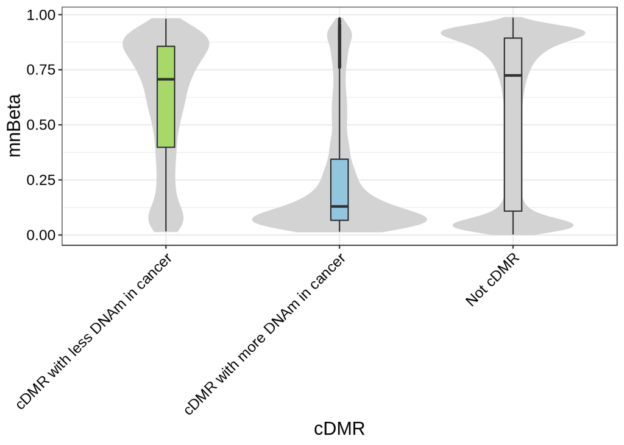

```r
CpG_mnBeta<-data.frame(CpG = names(rowMeans(organoid_beta)), mnBeta = rowMeans(organoid_beta))

CpG_mnBeta_dmr<-merge(cDMR, CpG_mnBeta, by="CpG")

ggplot(CpG_mnBeta_dmr, aes(cDMR, mnBeta)) + geom_violin(fill="lightgrey", color="lightgrey", width=1)+
  geom_boxplot(aes(fill=cDMR), width=0.1, outlier.size=0.5)+th+theme_bw() + scale_fill_manual(values=c("#a6d96a","#92c5de","lightgrey"))+
  theme(legend.position="none",
        axis.text = element_text(size =12, color="black"),
        axis.title = element_text(size =15),
        legend.text = element_text(size =14),
        legend.title = element_text(size =12),
        strip.text.x = element_text(size = 12),
        axis.text.x = element_text(size = 12, angle = 45, hjust=1))
```

```r
ggsave(here("figs","cDMR_CpGs_beta.pdf"),width = 4, height = 6)
ggsave(here("figs/jpeg","cDMR_CpGs_beta.jpeg"), width = 4, height = 6)
```

#### Monte carlo function on background of CpGs

```r
DMR_permutation_enrichment<-function(CpG_list,background.probes, permutation_number, plotmin,plotmax, axislab){
  cDMR_DMR<-cDMR[which(cDMR$cDMR!="Not cDMR"),]
  cDMR_DMR$cDMR<-as.factor(cDMR_DMR$cDMR)

  cDMR_hits<-cDMR_DMR[which(cDMR_DMR$CpG%in%CpG_list),]
  cDMR_hits_featureMeans<-tapply(cDMR_hits$CpG, cDMR_hits$cDMR, length)
  cDMR_hits_featureMeans[is.na(cDMR_hits_featureMeans)]<-0
  cDMR_hits_featureMeans<-data.frame(Probe_Count=as.numeric(cDMR_hits_featureMeans),
                                     Feature=names(cDMR_hits_featureMeans))
  cDMR_hits_featureMeans$Feature<-as.factor(cDMR_hits_featureMeans$Feature)

  # random sampling (to see if hits more in feature than expected)
  bootstrap_cDMR<-lapply(1:permutation_number, function(x){
    set.seed(x)
    Hit_number<-length(CpG_list)
    rnd_CpGs<-background.probes[sample(1:length(background.probes),Hit_number)]
    cDMR_rnd<-cDMR_DMR[which(cDMR_DMR$CpG%in%rnd_CpGs),]
    cDMR_rnd_featureMeans<-tapply(cDMR_rnd$CpG, cDMR_rnd$cDMR, length)
    cDMR_rnd_featureMeans[is.na(cDMR_rnd_featureMeans)]<-0
    cDMR_rnd_featureMeans
  })
  bootstrap_cDMR<-do.call(rbind,bootstrap_cDMR)

  cDMR_results<-lapply(1:nrow(cDMR_hits_featureMeans), function(x){
    real_CpG_in_region<-cDMR_hits_featureMeans$Probe_Count[x]
    Adjusted_enrich_p<-round(p.adjust((length(which(bootstrap_cDMR[,x]>=real_CpG_in_region))+1)/(permutation_number+1), method="fdr", n=nrow(cDMR_hits_featureMeans)),3)
    Adjusted_depletion_p<-round(p.adjust((length(which(bootstrap_cDMR[,x]<=real_CpG_in_region))+1)/(permutation_number+1), method="fdr", n=nrow(cDMR_hits_featureMeans)),3)
    print(paste("Feature: ", cDMR_hits_featureMeans$Feature[x], "   Enrichment: ", Adjusted_enrich_p, "; Depletion: ", Adjusted_depletion_p,  sep=""))

    data.frame(Feature = cDMR_hits_featureMeans$Feature[x],
               Enrichment = Adjusted_enrich_p,
               Depletion = Adjusted_depletion_p,
               Sig = if(Adjusted_enrich_p<0.05 | Adjusted_depletion_p<0.05){"*"}else{""})
  })

  cDMR_results<-do.call(rbind, cDMR_results)

  # Plot the fold change
  cDMR_hits_featureMeans$Fold_change<-sapply(1:nrow(cDMR_hits_featureMeans), function(x) mean(foldchange(cDMR_hits_featureMeans$Probe_Count[x], bootstrap_cDMR[,x])))
  cDMR_hits_featureMeans$Fold_change[is.infinite(cDMR_hits_featureMeans$Fold_change)]<-NA

  se <- function(x) sd(x)/sqrt(length(x))
  cDMR_hits_featureMeans$Fold_change_se<-sapply(1:nrow(cDMR_hits_featureMeans), function(x) se(foldchange(cDMR_hits_featureMeans$Probe_Count[x], bootstrap_cDMR[,x])))
  cDMR_hits_featureMeans$Fold_change_se[is.infinite(cDMR_hits_featureMeans$Fold_change_se)]<-NA

  cDMR_hits_featureMeans<-merge(cDMR_hits_featureMeans, cDMR_results, by="Feature")

  cDMR_hits_featureMeans$Feature<-as.factor(cDMR_hits_featureMeans$Feature)
  levels(cDMR_hits_featureMeans$Feature)<-c("cDMR with less\nDNAm in cancer", "cDMR with more\nDNAm in cancer")

  p<-ggplot(cDMR_hits_featureMeans, aes(Feature, Fold_change, fill=Feature))+ # don't know what just DMR is
          geom_bar(position=position_dodge(width=0.9),stat="identity", color="grey25")+theme_bw()+
          geom_errorbar(aes(ymax = Fold_change+Fold_change_se, ymin=Fold_change-Fold_change_se),width=0.25,position=position_dodge(width=0.9))+
          ylab("Fold Change")+xlab("")+ylim(plotmin,plotmax)+
          theme(legend.position="none",plot.margin = margin(0.5, 0.1, 0.1, 0.5, "cm"),
                axis.text = element_text(size =10, angle=45,color="black", hjust=1),
                axis.title = element_text(size =12),
                legend.text = element_text(size =12),
                legend.title = element_text(size =12),
                strip.text.x = element_text(size = 12))+
          geom_text(aes(label = Sig, y=7), size=6, color="grey40")+
          scale_fill_manual(values=c("#a6d96a","#92c5de"))

  if(missing(axislab)){p}else{
    if(axislab=="N"){p + theme(axis.title.y=element_blank(),
                               axis.text.y=element_blank(),
                               axis.ticks.y=element_blank())}else{p}}
}


cDMR_enrichment_hetero<-DMR_permutation_enrichment(hetero_CpG$IlmnID,background$IlmnID, 1000, -20,20)
```

```
## [1] "Feature: cDMR with less DNAm in cancer   Enrichment: 0.002; Depletion: 1"
## [1] "Feature: cDMR with more DNAm in cancer   Enrichment: 0.124; Depletion: 1"
```

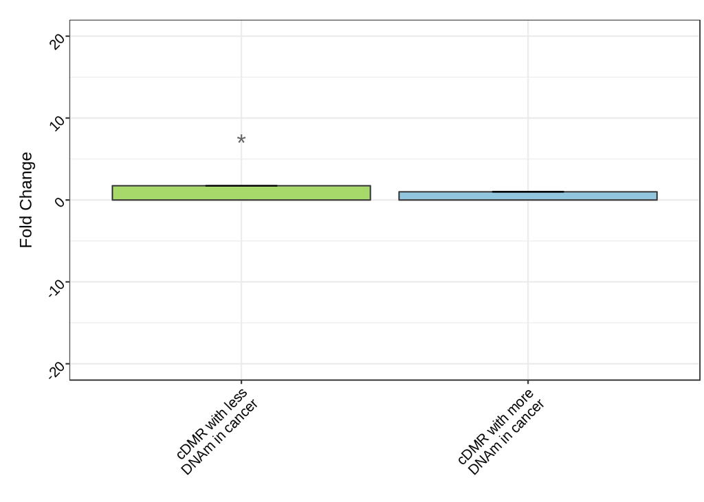

```r
cDMR_enrichment_hetero
```

```r
ggsave(here("figs","Passage_hetero_cDMR_CpGs_FDR.pdf"),width = 3, height = 6)
ggsave(here("figs/jpeg","Passage_hetero_cDMR_CpGs_FDR.jpeg"), width = 3, height = 6)

## with direction of effect backgrounds
cDMR_enrichment_diff_hypo<-DMR_permutation_enrichment(diff_CpG_hypo$IlmnID,background_hypo$IlmnID, 1000,-20,20)
```

```
## [1] "Feature: cDMR with less DNAm in cancer   Enrichment: 0.002; Depletion: 1"
## [1] "Feature: cDMR with more DNAm in cancer   Enrichment: 1; Depletion: 0.002"
```

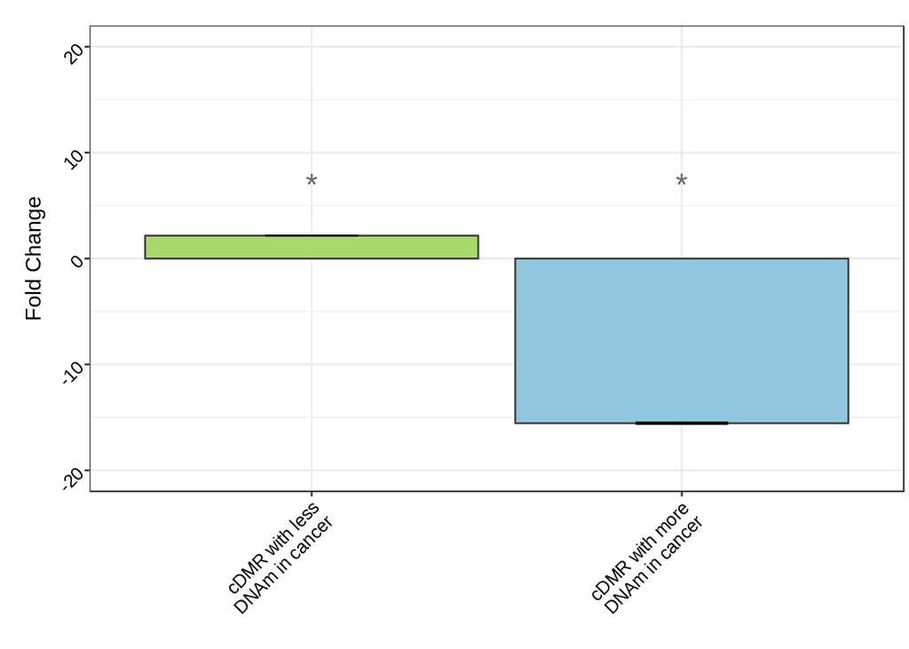

```r
cDMR_enrichment_diff_hypo
```

```r
ggsave(here("figs","Passage_diffhypo_cDMR_CpGs_FDR_background015.pdf"),width = 3, height = 6)
ggsave(here("figs/jpeg","Passage_diffhypo_cDMR_CpGs_FDR_background015.jpeg"), width = 3, height = 6)
cDMR_enrichment_diff_hyper<-DMR_permutation_enrichment(diff_CpG_hyper$IlmnID,background_hyper$IlmnID, 1000,-20,20)
```

```
## [1] "Feature: cDMR with less DNAm in cancer   Enrichment: 1; Depletion: 0.002"
## [1] "Feature: cDMR with more DNAm in cancer   Enrichment: 0.002; Depletion: 1"
```

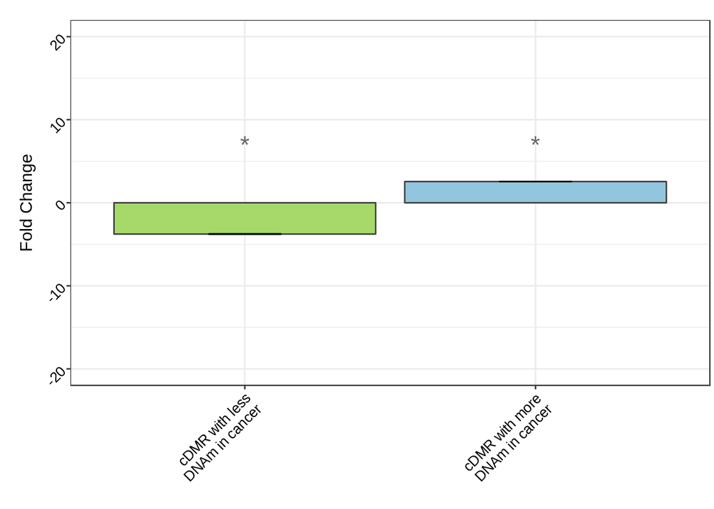

```r
cDMR_enrichment_diff_hyper
```

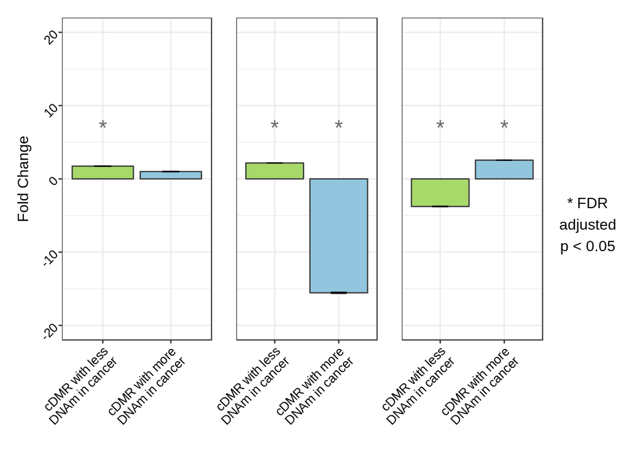

```
## [1] "Feature: cDMR with less DNAm in cancer   Enrichment: 0.002; Depletion: 1"
## [1] "Feature: cDMR with more DNAm in cancer   Enrichment: 0.124; Depletion: 1"
## [1] "Feature: cDMR with less DNAm in cancer   Enrichment: 0.002; Depletion: 1"
## [1] "Feature: cDMR with more DNAm in cancer   Enrichment: 1; Depletion: 0.002"
## [1] "Feature: cDMR with less DNAm in cancer   Enrichment: 1; Depletion: 0.002"
## [1] "Feature: cDMR with more DNAm in cancer   Enrichment: 0.002; Depletion: 1"
```

```r
ggsave(here("figs","Passage_diffhyper_cDMR_CpGs_FDR_background015.pdf"),width = 3, height = 6)
ggsave(here("figs/jpeg","Passage_diffhyper_cDMR_CpGs_FDR_background015.jpeg"), width = 3, height = 6)

t <- textGrob("* FDR\nadjusted\np < 0.05")

grid.arrange(DMR_permutation_enrichment(hetero_CpG$IlmnID,background$IlmnID, 1000, -20,20, "Y"),
             DMR_permutation_enrichment(diff_CpG_hypo$IlmnID,background_hypo$IlmnID, 1000,-20,20, "N"),
             DMR_permutation_enrichment(diff_CpG_hyper$IlmnID,background_hyper$IlmnID, 1000,-20,20, "N"), t, ncol=4, widths=c(1.3,1,1,0.5))
```

```r
ggsave(here("figs","Passage_hetero_hypo_hyper_DMR_CpGs_FDR_background015.pdf"),
       grid.arrange(DMR_permutation_enrichment(hetero_CpG$IlmnID,background$IlmnID, 1000, -20,20, "Y"),
                    DMR_permutation_enrichment(diff_CpG_hypo$IlmnID,background_hypo$IlmnID, 1000,-20,20, "N"),
                    DMR_permutation_enrichment(diff_CpG_hyper$IlmnID,background_hyper$IlmnID, 1000,-20,20, "N"), t, ncol=4, widths=c(1.3,1,1,0.5)),width = 8, height = 3)
```

```
## [1] "Feature: cDMR with less DNAm in cancer   Enrichment: 0.002; Depletion: 1"
## [1] "Feature: cDMR with more DNAm in cancer   Enrichment: 0.124; Depletion: 1"
## [1] "Feature: cDMR with less DNAm in cancer   Enrichment: 0.002; Depletion: 1"
## [1] "Feature: cDMR with more DNAm in cancer   Enrichment: 1; Depletion: 0.002"
## [1] "Feature: cDMR with less DNAm in cancer   Enrichment: 1; Depletion: 0.002"
## [1] "Feature: cDMR with more DNAm in cancer   Enrichment: 0.002; Depletion: 1"
```

```r
ggsave(here("figs/jpeg","Passage_hetero_hypo_hyper_DMR_CpGs_FDR_background015.jpeg"),
       grid.arrange(DMR_permutation_enrichment(hetero_CpG$IlmnID,background$IlmnID, 1000, -20,20, "Y"),
                    DMR_permutation_enrichment(diff_CpG_hypo$IlmnID,background_hypo$IlmnID, 1000,-20,20, "N"),
                    DMR_permutation_enrichment(diff_CpG_hyper$IlmnID,background_hyper$IlmnID, 1000,-20,20, "N"), t, ncol=4, widths=c(1.3,1,1,0.5)),width = 8, height = 3)
```

```
## [1] "Feature: cDMR with less DNAm in cancer   Enrichment: 0.002; Depletion: 1"
## [1] "Feature: cDMR with more DNAm in cancer   Enrichment: 0.124; Depletion: 1"
## [1] "Feature: cDMR with less DNAm in cancer   Enrichment: 0.002; Depletion: 1"
## [1] "Feature: cDMR with more DNAm in cancer   Enrichment: 1; Depletion: 0.002"
## [1] "Feature: cDMR with less DNAm in cancer   Enrichment: 1; Depletion: 0.002"
## [1] "Feature: cDMR with more DNAm in cancer   Enrichment: 0.002; Depletion: 1"
```

## Regulatory region enrichment

```r
EPIC_ensembl_annotation<-read.csv(here("data","EPIC_ensembl_reg_annotation.csv"), header=T)
head(EPIC_ensembl_annotation)
```

```
##   X Unnamed..0         X0                                X1
## 1 0          0 cg07881041                                []
## 2 1          1 cg18478105 ['CTCF Binding Site', 'Promoter']
## 3 2          2 cg23229610                                []
## 4 3          3 cg03513874                                []
## 5 4          4 cg05451842 ['CTCF Binding Site', 'Promoter']
## 6 5          5 cg14797042      ['Promoter Flanking Region']
```

```r
EPIC_ensembl_annotation<-EPIC_ensembl_annotation[,3:4]
colnames(EPIC_ensembl_annotation)<-c("CpG", "Feature")
```

Remove special characters and make one feature-CpG per row

```r
EPIC_ensembl_annotation_unique<-lapply(1:nrow(EPIC_ensembl_annotation), function(x) {
  Features=gsub("'","",strsplit(gsub("[^0-9A-Za-z///' ]","",as.character(EPIC_ensembl_annotation$Feature[x])), "' '")[[1]])
  if(length(Features)==0){Features<-"None"}else{}
  data.frame(CpG=EPIC_ensembl_annotation$CpG[x], Feature=Features)
})

EPIC_ensembl_annotation_unique<-do.call(rbind, EPIC_ensembl_annotation_unique)

head(EPIC_ensembl_annotation_unique)
```

```
##          CpG           Feature
## 1 cg07881041              None
## 2 cg18478105 CTCF Binding Site
## 3 cg18478105          Promoter
## 4 cg23229610              None
## 5 cg03513874              None
## 6 cg05451842 CTCF Binding Site
```

```r
print(paste("There are ",length(unique(EPIC_ensembl_annotation_unique[which(EPIC_ensembl_annotation_unique$Feature!="None"),]$CpG)),
            "/800383 CpGs in regulatory features, and ",sum(duplicated(EPIC_ensembl_annotation_unique$CpG))," in multiple features (mostly CTCF and Promoter)", sep=""))
```

```
## [1] "There are 460188/800383 CpGs in regulatory features, and 129697 in multiple features (mostly CTCF and Promoter)"
```

### Base EPIC array distribution

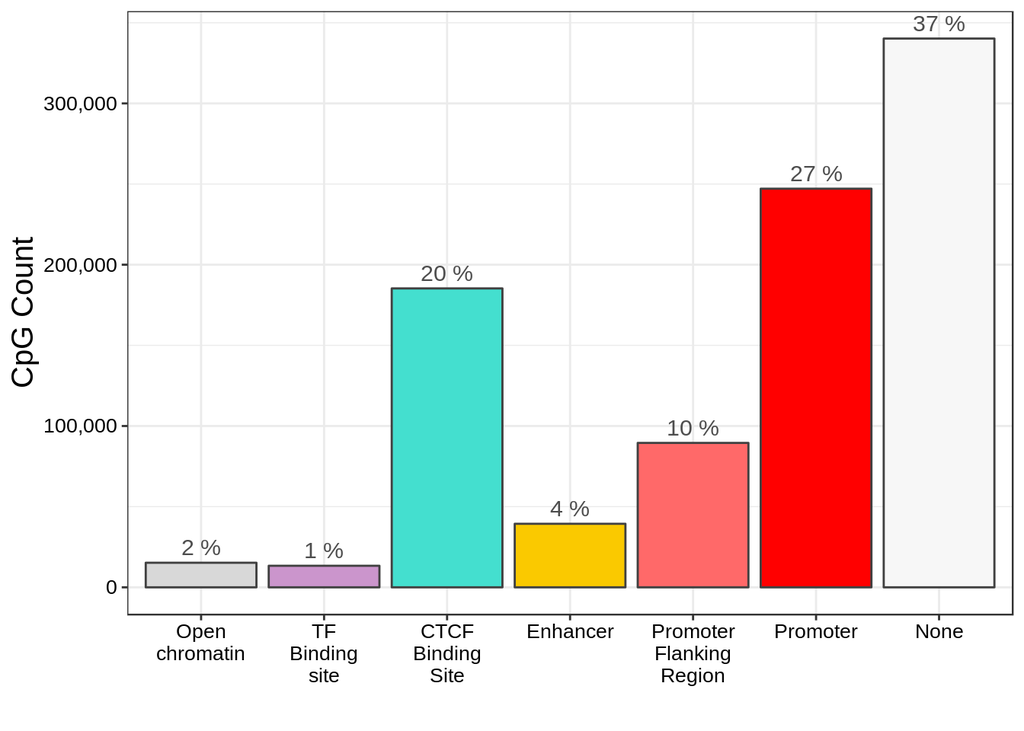

```r
EPIC_featureCount<-tapply(EPIC_ensembl_annotation_unique$CpG, EPIC_ensembl_annotation_unique$Feature, length)
EPIC_featureCount<-data.frame(CpG_Count=as.numeric(EPIC_featureCount),
                              Feature=names(EPIC_featureCount))
EPIC_featureCount$Feature<-factor(EPIC_featureCount$Feature,
                                  levels=c("Open chromatin","TF binding site","CTCF Binding Site",
                                           "Enhancer","Promoter Flanking Region",
                                           "Promoter", "None"))
levels(EPIC_featureCount$Feature)<-c("Open\nchromatin","TF\nBinding\nsite","CTCF\nBinding\nSite",
                                     "Enhancer","Promoter\nFlanking\nRegion",
                                     "Promoter", "None")
EPIC_featureCount$percent<-(EPIC_featureCount$CpG_Count/sum(EPIC_featureCount$CpG_Count))*100

ggplot(EPIC_featureCount, aes(Feature, CpG_Count, fill=Feature))+
  geom_bar(position=position_dodge(width=0.9),stat="identity", color="grey25")+theme_bw()+
  ylab("CpG Count")+xlab("")+th+
  theme(legend.position="none",
        axis.text = element_text(size =10, color="black"),
        axis.title = element_text(size =15),
        legend.text = element_text(size =14),
        legend.title = element_text(size =12),
        strip.text.x = element_text(size = 12))+
  geom_text(aes(label = paste (round(percent, 0), "%"), y=CpG_Count, vjust=-0.5), size=4, color="grey30")+
  scale_fill_manual(values=c("#d8d8d8","#cb95cc","#44dfcf","#fac900","#ff6969","#ff0000","grey97"))+
  scale_y_continuous(label=comma)
```

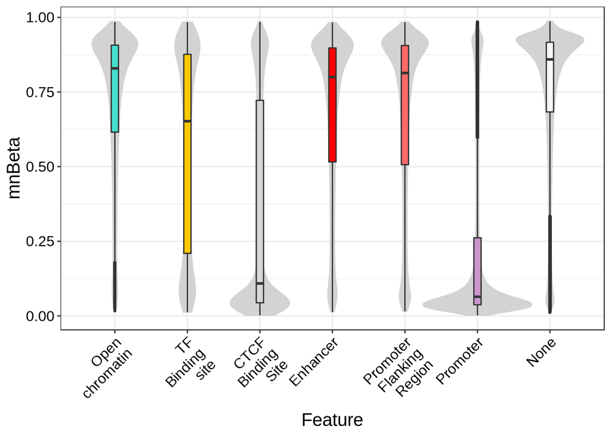

```r
ggsave(here("figs","EPIC_distribution_reg_CpGs.pdf"),width = 6, height = 6)
ggsave(here("figs/jpeg","EPIC_distribution_reg_CpGs.jpeg"), width = 6, height = 6)



# Overall methylation level of these regions across all samples
# Are some regions depleted for hypo cause they are already unmethylated

CpG_mnBeta<-data.frame(CpG = names(rowMeans(organoid_beta)), mnBeta = rowMeans(organoid_beta))
CpG_mnBeta_feature<-merge(EPIC_ensembl_annotation_unique, CpG_mnBeta, by = "CpG")
CpG_mnBeta_feature$Feature<-factor(CpG_mnBeta_feature$Feature,
                                   levels=c("Open chromatin","TF binding site","CTCF Binding Site",
                                            "Enhancer","Promoter Flanking Region",
                                            "Promoter", "None"))
levels(CpG_mnBeta_feature$Feature)<-c("Open\nchromatin","TF\nBinding\nsite","CTCF\nBinding\nSite",
                                      "Enhancer","Promoter\nFlanking\nRegion",
                                      "Promoter", "None")

ggplot(CpG_mnBeta_feature, aes(Feature, mnBeta)) + geom_violin(fill="lightgrey", color="lightgrey", width=1.5)+
  geom_boxplot(aes(fill=Feature), width=0.1, outlier.size=0.5)+th+theme_bw() + scale_fill_manual(values=c("#44dfcf","#fac900","#d8d8d8","#ff0000","#ff6969","#cb95cc","grey97"))+
  theme(legend.position="none",
        axis.text = element_text(size =12, color="black"),
        axis.title = element_text(size =15),
        legend.text = element_text(size =14),
        legend.title = element_text(size =12),
        strip.text.x = element_text(size = 12),
        axis.text.x = element_text(size = 12, angle = 45, hjust=1))
```

```r
ggsave(here("figs","EPIC_distribution_reg_CpGs_beta.pdf"),width = 8, height = 6)
ggsave(here("figs/jpeg","EPIC_distribution_reg_CpGs_beta.jpeg"), width = 8, height = 6)
```

#### Monte carlo function on background of CpGs

```r
regulation_permutation_enrichment<-function(CpG_list,background.probes, permutation_number, plotmin,plotmax, axislab){

  reg_hits<-EPIC_ensembl_annotation_unique[which(EPIC_ensembl_annotation_unique$CpG%in%CpG_list),]
  reg_hits_featureMeans<-tapply(reg_hits$CpG, reg_hits$Feature, length)
  reg_hits_featureMeans[is.na(reg_hits_featureMeans)]<-0
  reg_hits_featureMeans<-data.frame(Probe_Count=as.numeric(reg_hits_featureMeans),
                                    Feature=names(reg_hits_featureMeans))

  # random sampling (to see if hits more in feature than expected)
  bootstrap_reg<-lapply(1:permutation_number, function(x){
    set.seed(x)
    Hit_number<-length(CpG_list)
    rnd_CpGs<-background.probes[sample(1:length(background.probes),Hit_number)]
    reg_rnd<-EPIC_ensembl_annotation_unique[which(EPIC_ensembl_annotation_unique$CpG%in%rnd_CpGs),]
    reg_rnd_featureMeans<-tapply(reg_rnd$CpG, reg_rnd$Feature, length)
    reg_rnd_featureMeans[is.na(reg_rnd_featureMeans)]<-0
    reg_rnd_featureMeans
  })
  bootstrap_reg<-do.call(rbind,bootstrap_reg)

  reg_results<-lapply(1:nrow(reg_hits_featureMeans), function(x){
    real_CpG_in_region<-reg_hits_featureMeans$Probe_Count[x]

    Adjusted_enrich_p<-round(p.adjust((length(which(bootstrap_reg[,x]>=real_CpG_in_region))+1)/(permutation_number+1), method="fdr", n=nrow(reg_hits_featureMeans)),3)
    Adjusted_depletion_p<-round(p.adjust((length(which(bootstrap_reg[,x]<=real_CpG_in_region))+1)/(permutation_number+1), method="fdr", n=nrow(reg_hits_featureMeans)),3)
    print(paste("Feature: ", reg_hits_featureMeans$Feature[x], "   Enrichment: ", Adjusted_enrich_p, "; Depletion: ", Adjusted_depletion_p,  sep=""))

    data.frame(Feature = reg_hits_featureMeans$Feature[x],
               Enrichment = Adjusted_enrich_p,
               Depletion = Adjusted_depletion_p,
               Sig = if(Adjusted_enrich_p<0.05 | Adjusted_depletion_p<0.05){"*"}else{""})
  })
  reg_results<-do.call(rbind, reg_results)

  ## fold change
  reg_hits_featureMeans$Fold_change<-sapply(1:nrow(reg_hits_featureMeans), function(x) mean(foldchange(reg_hits_featureMeans$Probe_Count[x], bootstrap_reg[,x])))
  reg_hits_featureMeans$Fold_change[is.infinite(reg_hits_featureMeans$Fold_change)]<-NA
  se <- function(x) sd(x)/sqrt(length(x))
  reg_hits_featureMeans$Fold_change_se<-sapply(1:nrow(reg_hits_featureMeans), function(x) se(foldchange(reg_hits_featureMeans$Probe_Count[x], bootstrap_reg[,x])))
  reg_hits_featureMeans$Fold_change_se[is.infinite(reg_hits_featureMeans$Fold_change_se)]<-NA
  reg_hits_featureMeans<-merge(reg_hits_featureMeans, reg_results, by="Feature")

  reg_hits_featureMeans$Feature<-factor(reg_hits_featureMeans$Feature,
                                        levels=c("Open chromatin","TF binding site","CTCF Binding Site",
                                                 "Enhancer","Promoter Flanking Region",
                                                 "Promoter", "None"))

  levels(reg_hits_featureMeans$Feature)<-c("Open chromatin","TF Binding site","CTCF Binding Site",
                                           "Enhancer","Promoter Flanking Region",
                                           "Promoter", "None")

  p<-ggplot(reg_hits_featureMeans, aes(Feature, Fold_change, fill=Feature))+
    geom_hline(yintercept = reg_hits_featureMeans$Fold_change[which(reg_hits_featureMeans$Feature=="None")], color="grey25", size=0.5)+
          geom_bar(position=position_dodge(width=0.9),stat="identity", color="grey25")+theme_bw()+
          geom_errorbar(aes(ymax = Fold_change+Fold_change_se, ymin=Fold_change-Fold_change_se),width=0.25,position=position_dodge(width=0.9))+
          ylab("Fold Change")+xlab("")+ylim(plotmin,plotmax)+
          theme(legend.position="none",plot.margin = margin(0.5, 0.1, 0.1, 0.5, "cm"),
                axis.title = element_text(size =12),
                legend.text = element_text(size =14),
                legend.title = element_text(size =12),
                strip.text.x = element_text(size = 12),
                axis.text.x = element_text(size = 10, angle = 45, hjust=1, color="black"))+
          geom_text(aes(label = Sig, y=2.5), size=6, color="grey40")+
          scale_fill_manual(values=c("#d8d8d8","#cb95cc","#44dfcf","#fac900","#ff6969","#ff0000","grey97"))#+ geom_text(aes(label = Probe_Count, y=Fold_change, vjust=-0.8, hjust=0.1),angle = 45, size=3, color="grey30")#


  if(missing(axislab)){p}else{
    if(axislab=="N"){p + theme(axis.title.y=element_blank(),
                               axis.text.y=element_blank(),
                               axis.ticks.y=element_blank())}else{p}}
}



reg_enrichment_hetero<-regulation_permutation_enrichment(hetero_CpG$IlmnID,background$IlmnID, 1000, -5,5)
```

```
## [1] "Feature: CTCF Binding Site   Enrichment: 1; Depletion: 0.007"
## [1] "Feature: Enhancer   Enrichment: 0.007; Depletion: 1"
## [1] "Feature: None   Enrichment: 0.007; Depletion: 1"
## [1] "Feature: Open chromatin   Enrichment: 0.007; Depletion: 1"
## [1] "Feature: Promoter   Enrichment: 1; Depletion: 0.007"
## [1] "Feature: Promoter Flanking Region   Enrichment: 0.007; Depletion: 1"
## [1] "Feature: TF binding site   Enrichment: 0.007; Depletion: 1"
```

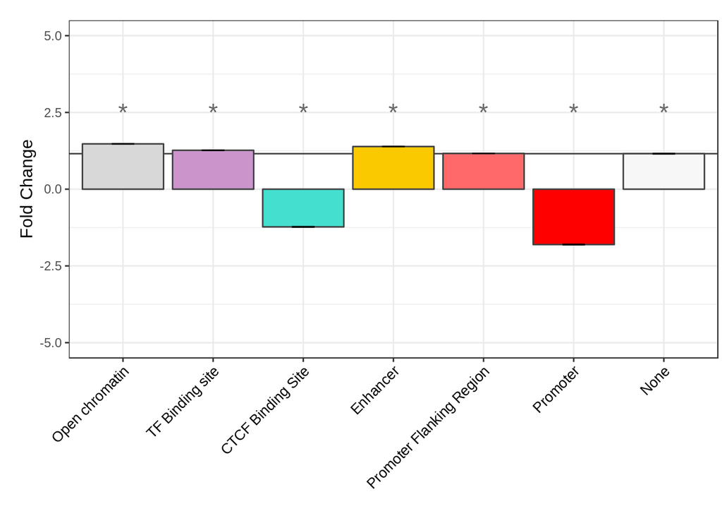

```r
reg_enrichment_hetero
```

```r
ggsave(here("figs","Passage_hetero_reg_CpGs_FDR.pdf"),width = 3, height = 6)
ggsave(here("figs/jpeg","Passage_hetero_reg_CpGs_FDR.jpeg"), width = 3, height = 6)

reg_enrichment_diff_hypo<-regulation_permutation_enrichment(diff_CpG_hypo$IlmnID,background_hypo$IlmnID, 1000,-5,5)
```

```
## [1] "Feature: CTCF Binding Site   Enrichment: 1; Depletion: 0.007"
## [1] "Feature: Enhancer   Enrichment: 0.007; Depletion: 1"
## [1] "Feature: None   Enrichment: 0.007; Depletion: 1"
## [1] "Feature: Open chromatin   Enrichment: 0.007; Depletion: 1"
## [1] "Feature: Promoter   Enrichment: 1; Depletion: 0.007"
## [1] "Feature: Promoter Flanking Region   Enrichment: 0.007; Depletion: 1"
## [1] "Feature: TF binding site   Enrichment: 1; Depletion: 0.007"
```

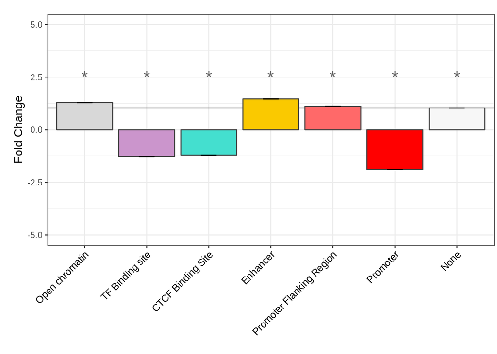

```r
reg_enrichment_diff_hypo
```

```r
ggsave(here("figs","Passage_diff_hypo_reg_CpGs_FDR_background015.pdf"),width = 3, height = 6)
ggsave(here("figs/jpeg","Passage_diff_hypo_reg_CpGs_FDR_background015.jpeg"), width = 3, height = 6)

reg_enrichment_diff_hyper<-regulation_permutation_enrichment(diff_CpG_hyper$IlmnID,background_hyper$IlmnID, 1000,-5,5)
```

```
## [1] "Feature: CTCF Binding Site   Enrichment: 1; Depletion: 0.007"
## [1] "Feature: Enhancer   Enrichment: 1; Depletion: 1"
## [1] "Feature: None   Enrichment: 0.007; Depletion: 1"
## [1] "Feature: Open chromatin   Enrichment: 0.357; Depletion: 1"
## [1] "Feature: Promoter   Enrichment: 1; Depletion: 0.007"
## [1] "Feature: Promoter Flanking Region   Enrichment: 0.007; Depletion: 1"
## [1] "Feature: TF binding site   Enrichment: 0.007; Depletion: 1"
```

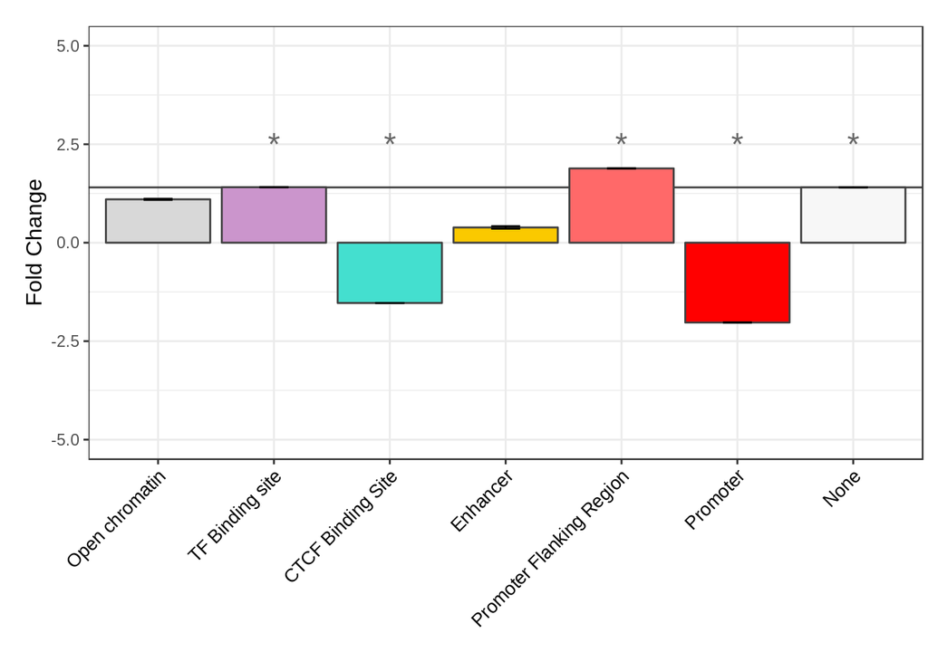

```r
reg_enrichment_diff_hyper
```

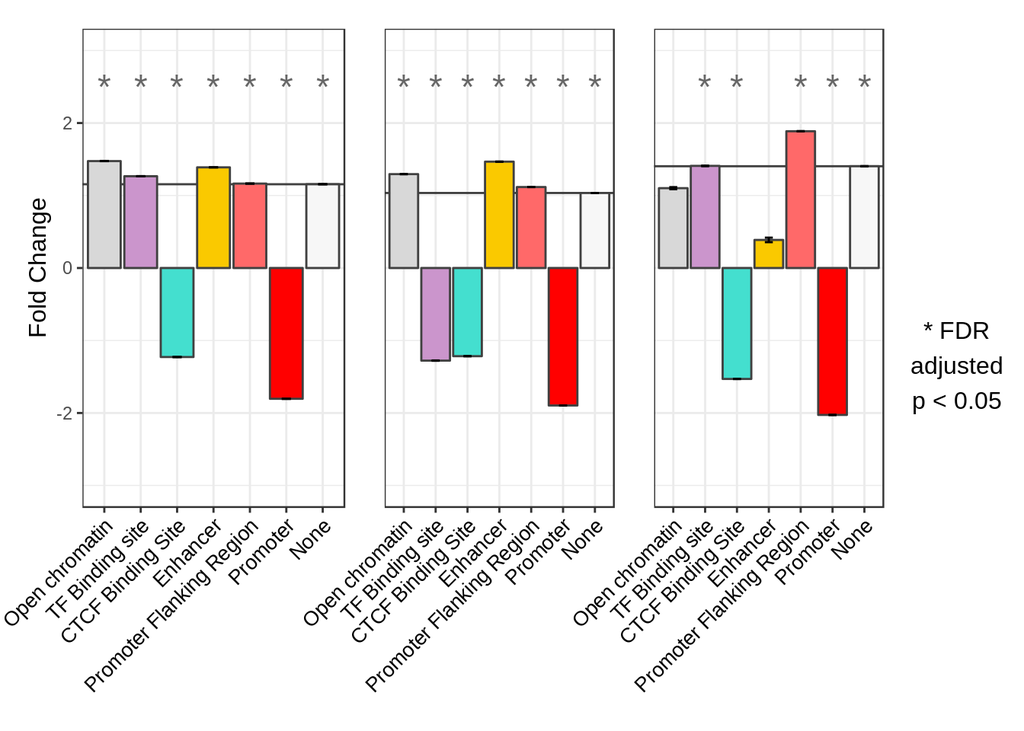

```
## [1] "Feature: CTCF Binding Site   Enrichment: 1; Depletion: 0.007"
## [1] "Feature: Enhancer   Enrichment: 0.007; Depletion: 1"
## [1] "Feature: None   Enrichment: 0.007; Depletion: 1"
## [1] "Feature: Open chromatin   Enrichment: 0.007; Depletion: 1"
## [1] "Feature: Promoter   Enrichment: 1; Depletion: 0.007"
## [1] "Feature: Promoter Flanking Region   Enrichment: 0.007; Depletion: 1"
## [1] "Feature: TF binding site   Enrichment: 0.007; Depletion: 1"
## [1] "Feature: CTCF Binding Site   Enrichment: 1; Depletion: 0.007"
## [1] "Feature: Enhancer   Enrichment: 0.007; Depletion: 1"
## [1] "Feature: None   Enrichment: 0.007; Depletion: 1"
## [1] "Feature: Open chromatin   Enrichment: 0.007; Depletion: 1"
## [1] "Feature: Promoter   Enrichment: 1; Depletion: 0.007"
## [1] "Feature: Promoter Flanking Region   Enrichment: 0.007; Depletion: 1"
## [1] "Feature: TF binding site   Enrichment: 1; Depletion: 0.007"
## [1] "Feature: CTCF Binding Site   Enrichment: 1; Depletion: 0.007"
## [1] "Feature: Enhancer   Enrichment: 1; Depletion: 1"
## [1] "Feature: None   Enrichment: 0.007; Depletion: 1"
## [1] "Feature: Open chromatin   Enrichment: 0.357; Depletion: 1"
## [1] "Feature: Promoter   Enrichment: 1; Depletion: 0.007"
## [1] "Feature: Promoter Flanking Region   Enrichment: 0.007; Depletion: 1"
## [1] "Feature: TF binding site   Enrichment: 0.007; Depletion: 1"
```

```r
ggsave(here("figs","Passage_diff_hyper_reg_CpGs_FDR_background015.pdf"),width = 3, height = 6)
ggsave(here("figs/jpeg","Passage_diff_hyper_reg_CpGs_FDR_background015.jpeg"), width = 3, height = 6)



## multipanel
t <- textGrob("* FDR\nadjusted\np < 0.05")



grid.arrange(regulation_permutation_enrichment(hetero_CpG$IlmnID,background$IlmnID, 1000, -3,3, "Y"),
             regulation_permutation_enrichment(diff_CpG_hypo$IlmnID,background_hypo$IlmnID, 1000,-3,3, "N"),
             regulation_permutation_enrichment(diff_CpG_hyper$IlmnID,background_hyper$IlmnID, 1000,-3,3, "N"), t, ncol=4, widths=c(1.3,1,1,0.5))
```

```r
ggsave(here("figs","Passage_hetero_hypo_hyper_reg_CpGs_FDR_background015.pdf"),
       grid.arrange(regulation_permutation_enrichment(hetero_CpG$IlmnID,background$IlmnID, 1000, -3,3, "Y"),
                    regulation_permutation_enrichment(diff_CpG_hypo$IlmnID,background_hypo$IlmnID, 1000,-3,3, "N"),
                    regulation_permutation_enrichment(diff_CpG_hyper$IlmnID,background_hyper$IlmnID, 1000,-3,3, "N"), t, ncol=4, widths=c(1.3,1,1,0.5)),width = 8, height = 4)
```

```
## [1] "Feature: CTCF Binding Site   Enrichment: 1; Depletion: 0.007"
## [1] "Feature: Enhancer   Enrichment: 0.007; Depletion: 1"
## [1] "Feature: None   Enrichment: 0.007; Depletion: 1"
## [1] "Feature: Open chromatin   Enrichment: 0.007; Depletion: 1"
## [1] "Feature: Promoter   Enrichment: 1; Depletion: 0.007"
## [1] "Feature: Promoter Flanking Region   Enrichment: 0.007; Depletion: 1"
## [1] "Feature: TF binding site   Enrichment: 0.007; Depletion: 1"
## [1] "Feature: CTCF Binding Site   Enrichment: 1; Depletion: 0.007"
## [1] "Feature: Enhancer   Enrichment: 0.007; Depletion: 1"
## [1] "Feature: None   Enrichment: 0.007; Depletion: 1"
## [1] "Feature: Open chromatin   Enrichment: 0.007; Depletion: 1"
## [1] "Feature: Promoter   Enrichment: 1; Depletion: 0.007"
## [1] "Feature: Promoter Flanking Region   Enrichment: 0.007; Depletion: 1"
## [1] "Feature: TF binding site   Enrichment: 1; Depletion: 0.007"
## [1] "Feature: CTCF Binding Site   Enrichment: 1; Depletion: 0.007"
## [1] "Feature: Enhancer   Enrichment: 1; Depletion: 1"
## [1] "Feature: None   Enrichment: 0.007; Depletion: 1"
## [1] "Feature: Open chromatin   Enrichment: 0.357; Depletion: 1"
## [1] "Feature: Promoter   Enrichment: 1; Depletion: 0.007"
## [1] "Feature: Promoter Flanking Region   Enrichment: 0.007; Depletion: 1"
## [1] "Feature: TF binding site   Enrichment: 0.007; Depletion: 1"
```

```r
ggsave(here("figs/jpeg","Passage_hetero_hypo_hyper_reg_CpGs_FDR_background015.jpeg"),
       grid.arrange(regulation_permutation_enrichment(hetero_CpG$IlmnID,background$IlmnID, 1000, -3,3, "Y"),
                    regulation_permutation_enrichment(diff_CpG_hypo$IlmnID,background_hypo$IlmnID, 1000,-3,3, "N"),
                    regulation_permutation_enrichment(diff_CpG_hyper$IlmnID,background_hyper$IlmnID, 1000,-3,3, "N"), t, ncol=4, widths=c(1.3,1,1,0.5)),width = 8, height = 4)
```

```
## [1] "Feature: CTCF Binding Site   Enrichment: 1; Depletion: 0.007"
## [1] "Feature: Enhancer   Enrichment: 0.007; Depletion: 1"
## [1] "Feature: None   Enrichment: 0.007; Depletion: 1"
## [1] "Feature: Open chromatin   Enrichment: 0.007; Depletion: 1"
## [1] "Feature: Promoter   Enrichment: 1; Depletion: 0.007"
## [1] "Feature: Promoter Flanking Region   Enrichment: 0.007; Depletion: 1"
## [1] "Feature: TF binding site   Enrichment: 0.007; Depletion: 1"
## [1] "Feature: CTCF Binding Site   Enrichment: 1; Depletion: 0.007"
## [1] "Feature: Enhancer   Enrichment: 0.007; Depletion: 1"
## [1] "Feature: None   Enrichment: 0.007; Depletion: 1"
## [1] "Feature: Open chromatin   Enrichment: 0.007; Depletion: 1"
## [1] "Feature: Promoter   Enrichment: 1; Depletion: 0.007"
## [1] "Feature: Promoter Flanking Region   Enrichment: 0.007; Depletion: 1"
## [1] "Feature: TF binding site   Enrichment: 1; Depletion: 0.007"
## [1] "Feature: CTCF Binding Site   Enrichment: 1; Depletion: 0.007"
## [1] "Feature: Enhancer   Enrichment: 1; Depletion: 1"
## [1] "Feature: None   Enrichment: 0.007; Depletion: 1"
## [1] "Feature: Open chromatin   Enrichment: 0.357; Depletion: 1"
## [1] "Feature: Promoter   Enrichment: 1; Depletion: 0.007"
## [1] "Feature: Promoter Flanking Region   Enrichment: 0.007; Depletion: 1"
## [1] "Feature: TF binding site   Enrichment: 0.007; Depletion: 1"
```